# 逻辑回归-糖尿病预测

## 一、相关模块导入部分

### 步骤：按要求导入相关数据读取、处理、分析、可视化，算法模块等

```python
import warnings
warnings.filterwarnings('ignore')
# 画图
%matplotlib inline
```

## 二、数据导入与初步探索部分

### 步骤 1 要求载入本地数据集(pima-indians-diabetes.data)，以dataframe形式存放后，命名为df

```python
import pandas as pd
import numpy as np
df= pd.read_csv(r'.\pima-indians-diabetes.data',sep=',')
#观察数据
print(df.shape)
df.head()
```

```
(768, 9)
```

|  | Pregnancies | Glucose | BloodPressure | SkinThickness | Insulin | BMI | DiabetesPedigreeFuction | Age | Outcome |
| --- | --- | --- | --- | --- | --- | --- | --- | --- | --- |
| 0 | 6 | 148 | 72 | 35 | 0 | 33.6 | 0.63 | 50 | 1 |
| 1 | 1 | 85 | 66 | 29 | 0 | 26.6 | 0.35 | 31 | 0 |
| 2 | 8 | 183 | 64 | 0 | 0 | 23.3 | 0.67 | 32 | 1 |
| 3 | 1 | 89 | 66 | 23 | 94 | 28.1 | 0.17 | 21 | 0 |
| 4 | 0 | 137 | 40 | 35 | 168 | 43.1 | 2.29 | 33 | 1 |

### 步骤 2 查看数据尺寸、打印信息，判断特征的类型（名称性、数值型），目标变量分布以及查看是否均衡

利用head函数，可以看到：糖尿病数据集由768个数据点组成，各有9个特征，特征分别是：怀孕次数，血糖，血压，皮脂厚度，胰岛素，BMI身体质量指数，糖尿病遗传函数，年龄和结果，此处是一个数据框格式，前8个特征均是数值型属性，最后1列是目标向量，是我们将要预测的特征，其中0意味着未患糖尿病，1意味着患有糖尿病。

```python
df.info()
```

```
<class 'pandas.core.frame.DataFrame'>
RangeIndex: 768 entries, 0 to 767
Data columns (total 9 columns):
 #   Column                   Non-Null Count  Dtype
---  ------                   --------------  -----
 0   Pregnancies              768 non-null    int64
 1   Glucose                  768 non-null    int64
 2   BloodPressure            768 non-null    int64
 3   SkinThickness            768 non-null    int64
 4   Insulin                  768 non-null    int64
 5   BMI                      768 non-null    float64
 6   DiabetesPedigreeFuction  768 non-null    float64
 7   Age                      768 non-null    int64
 8   Outcome                  768 non-null    int64
dtypes: float64(2), int64(7)
memory usage: 54.1 KB
```

```python
df['Outcome'].value_counts()
```

```
0    500
1    268
Name: Outcome, dtype: int64
```

### 步骤 3 对df特征进行相关性可视化

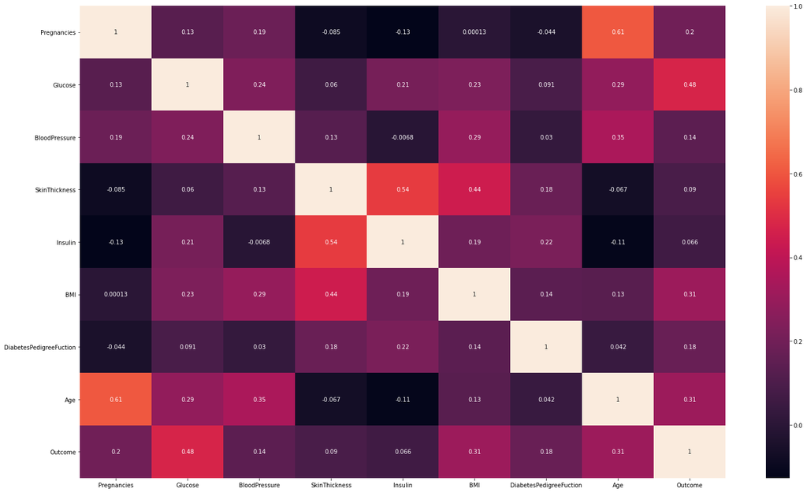

```python
%matplotlib inline
import seaborn as sns
import matplotlib.pyplot as plt
#对df特征进行相关性可视化
corr_matrix = df.corr(method='spearman')
plt.figure(figsize=(25, 15))
sns.heatmap(corr_matrix, annot= True)
```

### 步骤 4 对df每个特征的分布进行可视化查看

```python
import math
#对df每个特征的分布进行可视化查看
def plot_distribution(dataset, cols=5, width=20, height=15, hspace=0.2, wspace=0.5):
    plt.style.use('seaborn-whitegrid')
    fig = plt.figure(figsize=(width,height))
    fig.subplots_adjust(left=None, bottom=None, right=None, top=None, wspace=wspace, hspace=hspace) # 调整图表位置和大小间距
    rows = math.ceil(float(dataset.shape[1]) / cols)# ceil方法向上取整
    for i, column in enumerate(dataset.columns): #返回索引和列名
        ax = fig.add_subplot(rows, cols, i + 1)# 创建子图，类似于subplot方法
        ax.set_title(column)	# 设置轴的标题
        if dataset.dtypes[column] == np.object: # 通过列的类型来区分所选取的图像类型
            g = sns.countplot(y=column, data=dataset)
            substrings = [s.get_text()[:18] for s in g.get_yticklabels()]
            g.set(yticklabels=substrings)
            plt.xticks(rotation=25)
        else:
            g = sns.distplot(dataset[column])
            plt.xticks(rotation=25)
```

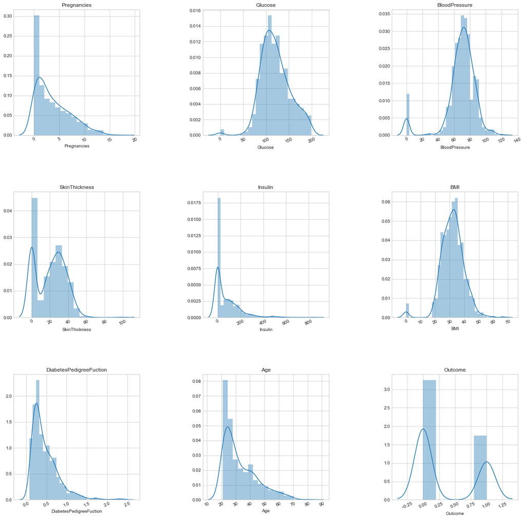

```python
plot_distribution(df, cols=3, width=20, height=20, hspace=0.45, wspace=0.5)
```

```python
from sklearn.model_selection import train_test_split
from collections import Counter
x_cols = [col for col in df.columns if col!='Outcome']
y_col = 'Outcome'
X=df[x_cols].values    #dataframe 转化为 ndarray
y=df[y_col].values
```

[figure not shown]

```python
### 绘制3D散点图-3个维度的数据点的散点分布
import matplotlib.pyplot as plt
from mpl_toolkits.mplot3d import Axes3D
ax = Axes3D(plt.figure())
for c,m,i,l in zip('rg','sx',np.unique(y),['class_1','class_2']):
    ax.scatter(X[y==i ,0], X[y==i, 4], X[y==i, 6],c=c,marker=m, label=l)
ax.set_xlabel(df.columns[1])
ax.set_ylabel(df.columns[5])
ax.set_zlabel(df.columns[7])
ax.set_title("pima-indians-diabetes")
plt.legend()
plt.show()
```